# Assignment_4

Steve Li

2017年12月4日

reading the file for bank data

```r
library(tidyverse)
bank<-read.csv("https://goo.gl/PBQnBt", sep = ";")
```

1. The younger people are easier to default then elder people. For elder people, entrepreneurs and self-employed people have more probability to default.

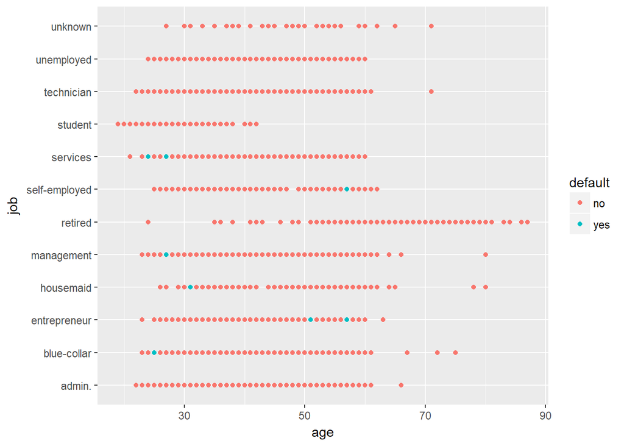

```r
ggplot(bank, aes(age, job, color = default)) + geom_point()
```

2. Elder people tend to only recevie primary education. Younger people have more chance to receive higher education.

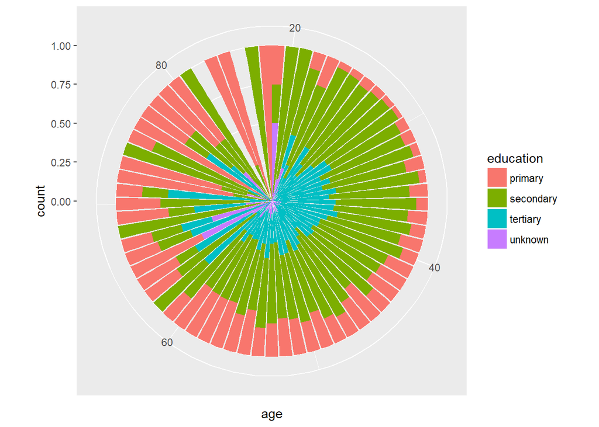

```r
ggplot(bank) +
geom_bar(mapping = aes(x = age, fill = education), position = "fill") +
coord_polar()
```

3. The people who got divorce tend to have lower balance. That means people who are divorced tend to have higher credit risk.

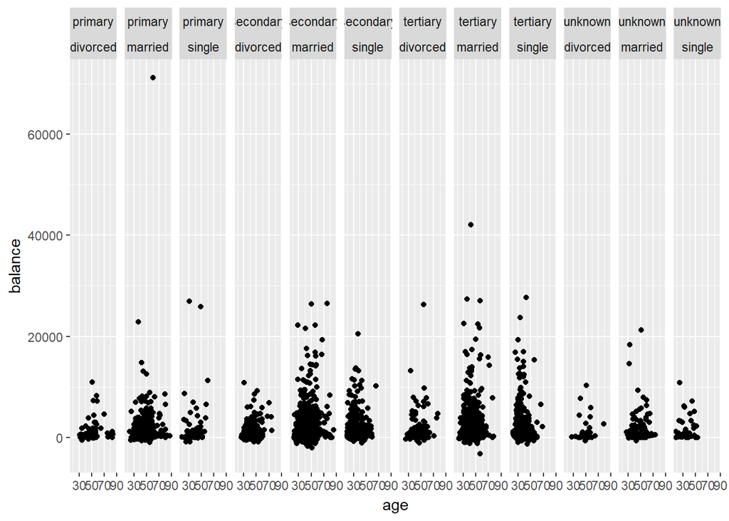

```r
ggplot(data = bank) +
geom_point(mapping = aes(x = age, y = balance)) +
facet_wrap(education ~ marital, nrow = 1)
```

4. Our sample is mainly from age 30 to age 50. The reason may be that the people less than 20 may not have credit card, and people more than 60 may not like to use credit card. The elder group may prefer to use cash.

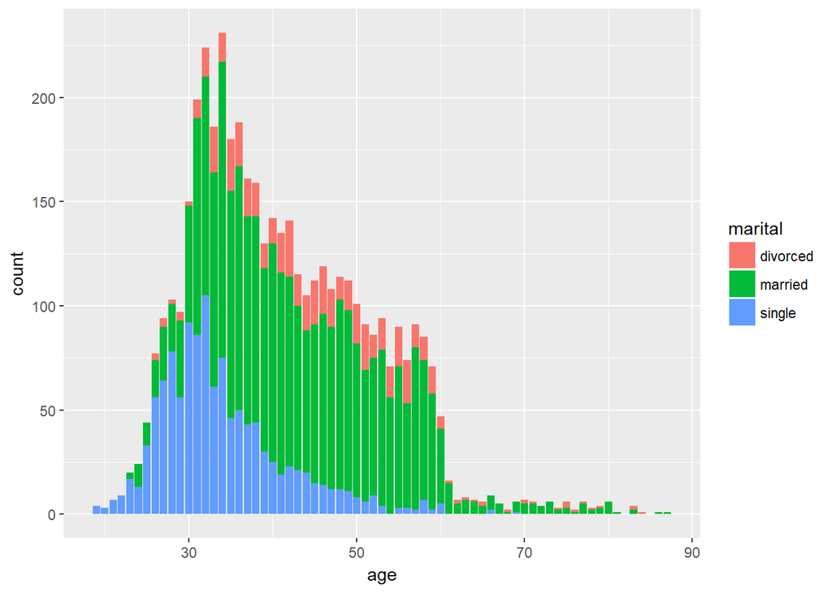

```r
ggplot(bank)+geom_bar(mapping=aes(x=age, fill=marital))
```

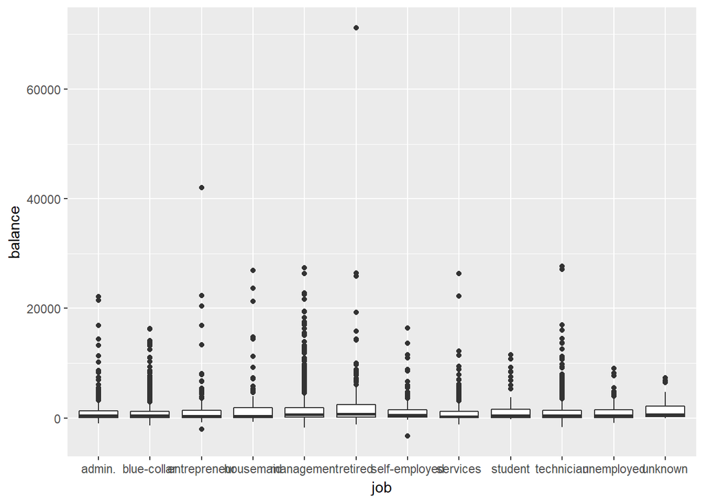

```r
ggplot(bank, aes(job,balance))+geom_boxplot()
```

6. From the chart, management have higher dencity to get divorce.

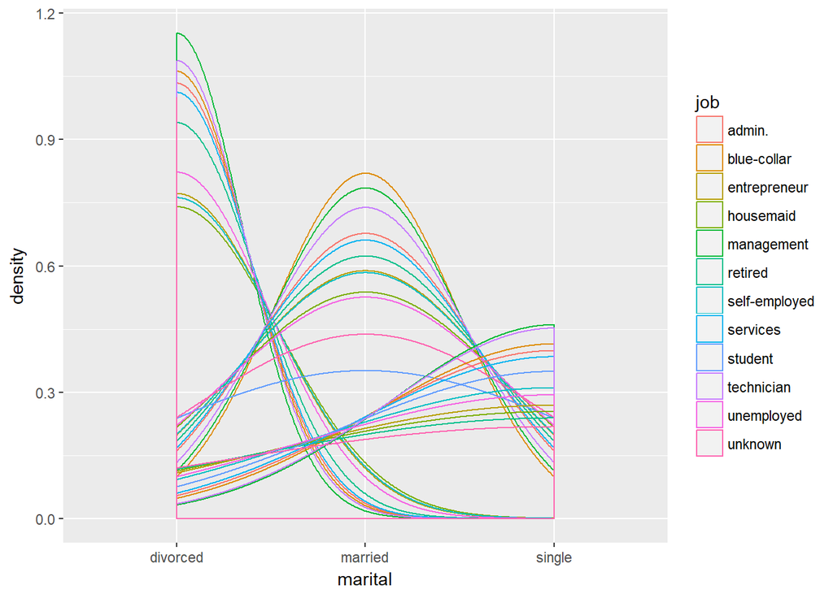

```r
ggplot(bank, aes(marital, color = job))+geom_density()
```

7. From the chart, we can see the marital status for different job.

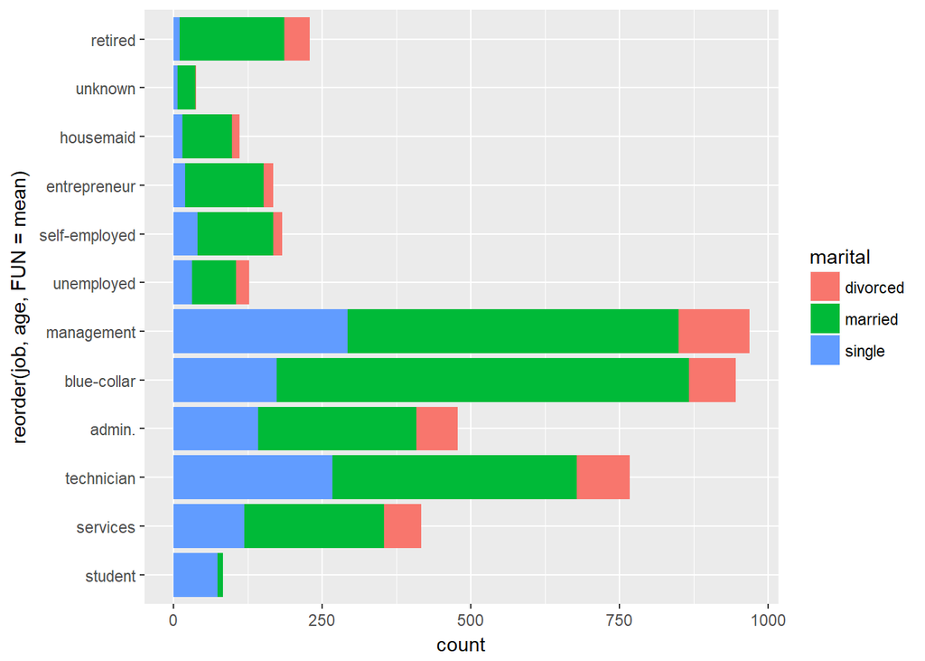

```r
ggplot(data = bank, mapping=aes(x=reorder(job, age, FUN=mean), fill=marital))+
  geom_bar()+coord_flip()
```

8. From the chart, elder people prefer to use telephone to contact.

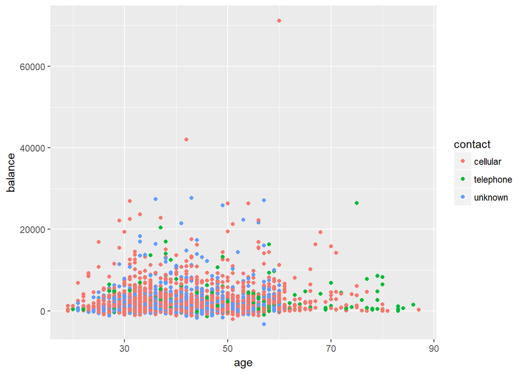

```r
ggplot(bank) + geom_point(aes(age, balance, color = contact))
```

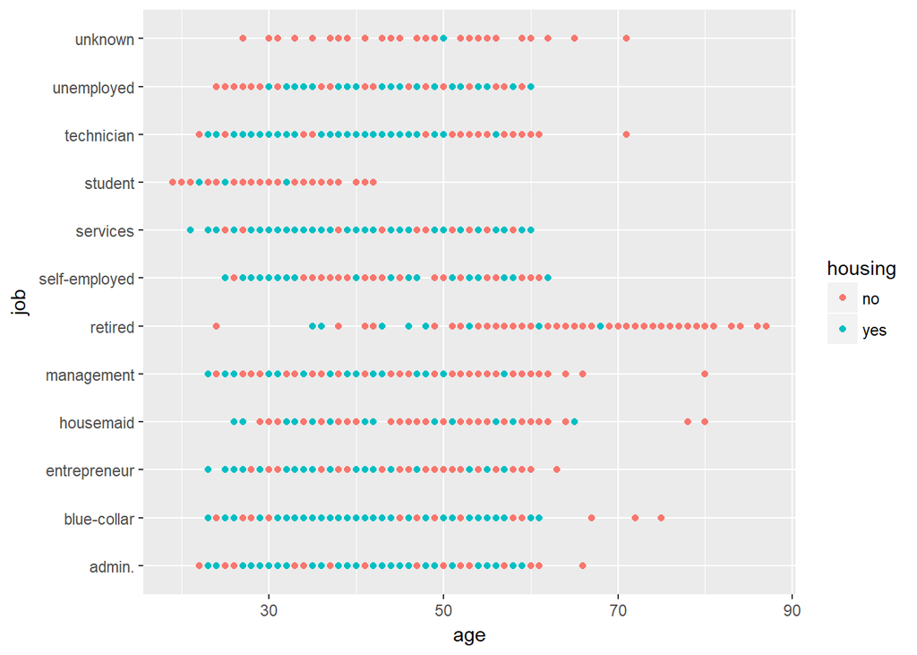

```r
ggplot(bank, aes(age, job, color = housing))+geom_point()
```

10. From the chart, people usually avoid having loan when becoming elder.

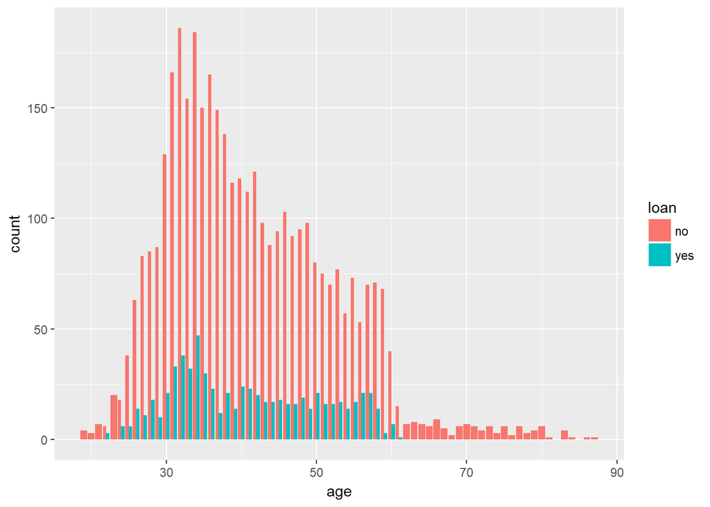

```r
ggplot(bank)+geom_bar(mapping=aes(x=age,fill=loan), position="dodge")
```